# monotonicGenes

Janis Corona

8/14/2020

GSE152418, 34 samples, 18 females, 16 males, aged 23-91. One convalescent sample, and a mixed number of samples in moderate, severe, and ICU grades of COVID-19 infection symptoms. The previous files for how this data was obtained are ‘covid19_GSE152418_76patients_1.Rmd’, and ‘2’ and ‘3’ for updated versions. It says 76 patients, because I recopied some code from a prior study using GSE151161 on COVID-19 symptoms that are similar to Rheumatoid Arthritis patients that had 76 samples but actually only had 38 patients.

(8/22/2020) Note, most of this document assumed the convalescent sample was a convalescent misclassified patient and that all samples are convalescent patients, but this is completely wrong. Convalescent is a medical terminology, to mean those healing or someone who has headed or survived a disease and thus generated antibodies. This sample is classified as a healthy sample in the ML done mid document, because it technically is and the range of values in gene expression are in the range of those healthy. This adds a new angle to look at the data, especially the charts of scatter with the ages, and know that the vitamin and hormone genes looked up are not influenced by convalescent homes giving the patients medicine. They are regular (possible citizens and not incarcerated) patients agreeing to have their blood taken and experimented on. I would never have caught this unless I watched a very annoying video and had to listen to it but had to do some exploring of other diseases to get my mind going on other projects (lime disease and ‘ticks’) where the summary used the ‘convalescing blood’ or similar which made me look it up. Its like a pun that retards the meaning completely.

This script is to test the topic modeling algorithm,linear discriminant analysis (lda), on these wide matrices of genes once we convert them to such. Caret will be used for the lda model.

We can use our functions find25genes and the other geneCards2.R script has.

```r
library(caret)
library(dplyr)
library(tidyr)
```

```r
monotonicIncrease <- read.csv('monotonicIncrease.csv',sep=',',
                      na.strings=c('',' ','NA'),header=T, stringsAsFactors = F)
monotonicDecrease <- read.csv('monotonicDecrease.csv',sep=',',
                      na.strings=c('',' ','NA'),header=T, stringsAsFactors = F)

HeaderInformation <- read.csv('HeaderInformation.csv',sep=',',
                              header=T, na.strings=c('',' ','NA'),
                              stringsAsFactors = F)
```

```r
head(HeaderInformation)
```

```
##       GSM_ID   CN_old   CN_new age gender diseaseState severity
## 1 GSM4615003 S061_257 healthy1  25      M      Healthy  Healthy
## 2 GSM4615006 S062_258 healthy2  70      F      Healthy  Healthy
## 3 GSM4615008 S063_259 healthy3  68      F      Healthy  Healthy
## 4 GSM4615011 S064_260 healthy4  69      M      Healthy  Healthy
## 5 GSM4615014 S065_261 healthy5  29      F      Healthy  Healthy
## 6 GSM4615016 S066_265 healthy6  90      M      Healthy  Healthy
##   geographicLocation cellType
## 1   Atlanta, GA, USA     PBMC
## 2   Atlanta, GA, USA     PBMC
## 3   Atlanta, GA, USA     PBMC
## 4   Atlanta, GA, USA     PBMC
## 5   Atlanta, GA, USA     PBMC
## 6   Atlanta, GA, USA     PBMC
```

```r
monotonicIncreaseOrder10 <- monotonicIncrease[order(monotonicIncrease$ICU_health_foldChange,decreasing=T)[1:10],]

monotonicDecreaseOrder10 <- monotonicDecrease[order(monotonicDecrease$ICU_health_foldChange, decreasing=T)[1:10],]


colnames(monotonicIncreaseOrder10)
```

```
##  [1] "ENSEMBLID"              "convalescent"           "healthy1"
##  [4] "healthy2"               "healthy3"               "healthy4"
##  [7] "healthy5"               "healthy6"               "healthy7"
## [10] "healthy8"               "healthy9"               "healthy10"
## [13] "healthy11"              "healthy12"              "healthy13"
## [16] "healthy14"              "healthy15"              "healthy16"
## [19] "healthy17"              "moderate1"              "moderate2"
## [22] "moderate3"              "moderate4"              "severe1"
## [25] "severe2"                "severe3"                "severe4"
## [28] "severe5"                "severe6"                "severe7"
## [31] "severe8"                "ICU1"                   "ICU2"
## [34] "ICU3"                   "ICU4"                   "healthy_mean"
## [37] "moderate_mean"          "severe_mean"            "ICU_mean"
## [40] "mod_health_foldChange"  "sevr_health_foldChange" "ICU_health_foldChange"
## [43] "monotonicIncrease"      "monotonicDecrease"
```

Lets only keep the actual samples for each class and set aside the convalescent sole sample.

```r
convalescentDecr <- monotonicDecreaseOrder10$convalescent
convalescentIncr <- monotonicIncreaseOrder10$convalescent

ensemblID <- monotonicIncreaseOrder10$ENSEMBLID

monotonicIncrease2 <- monotonicIncreaseOrder10[,c(3:35)]
monotonicDecrease2 <- monotonicDecreaseOrder10[,c(3:35)]

sampleType <- c(rep('healthy',17),rep('moderate',4),
                rep('severe',8),rep('ICU',4))
```

Make the two data frames matrices that flip the samples in the header for the rows and genes as the header from the EnsemblID feature.

```r
tIncr <- as.data.frame(t(monotonicIncrease2))
colnames(tIncr) <- ensemblID
tIncr$sample <- sampleType
IncreaseMx <- tIncr[,c(11,1:10)]
```

```r
set.seed(8989)

inTrain <- createDataPartition(y=IncreaseMx$sample, p=0.7, list=FALSE)

trainingSet <- IncreaseMx[inTrain,]
testingSet <- IncreaseMx[-inTrain,]
dim(trainingSet)
```

```
## [1] 24 11
```

```r
dim(testingSet)
```

```
## [1]  9 11
```

When using all 8088 genes as tokens for lda, it fails with accuracy and kappa values NA. So it was reduced to the top 10 highest fold change values in the ICU/healthy means. I origninally thought we were using the latent dirichlet allocation model of caret, but it is linear discriminant analysis of caret. This is why it fails. I do want to use the latent dirichlet allocation model, but it won’t be in caret. It is another R package.

```r
IncreaseMx$sample <- as.factor(paste(IncreaseMx$sample))
set.seed(505005)

ldaMod <- train(sample~., method='lda', data=trainingSet,
                preProc = c("center", "scale"),
                trControl=trainControl(method='boot'))
predlda <- predict(ldaMod, testingSet)

DF_ldaI <- data.frame(predlda, type=testingSet$sample)
DF_ldaI
```

```
##   predlda     type
## 1 healthy  healthy
## 2 healthy  healthy
## 3 healthy  healthy
## 4 healthy  healthy
## 5 healthy  healthy
## 6  severe moderate
## 7 healthy   severe
## 8     ICU   severe
## 9     ICU      ICU
```

```r
errored1 <- DF_ldaI[(DF_ldaI$predlda != DF_ldaI$type),]
errored1
```

```
##   predlda     type
## 6  severe moderate
## 7 healthy   severe
## 8     ICU   severe
```

```r
rn <- as.numeric(row.names(errored1))
rn
```

```
## [1] 6 7 8
```

```r
ldaError <- testingSet[rn,]
ldaError
```

```
##             sample ENSG00000133742 ENSG00000206177 ENSG00000158578
## moderate1 moderate               3               0               2
## severe1     severe               3               1              10
## severe7     severe             152             136            2513
##           ENSG00000223609 ENSG00000204010 ENSG00000169877 ENSG00000170180
## moderate1               1               3               0               4
## severe1                11               0               4               1
## severe7               330              12             100               3
##           ENSG00000143416 ENSG00000112077 ENSG00000076864
## moderate1               2               2               2
## severe1                 4               0               5
## severe7               270              14              17
```

```r
Inc_lda_wrong <- row.names(ldaError)
```

```r
lda_demg <- HeaderInformation[HeaderInformation$CN_new %in% row.names(ldaError),]
lda_demg
```

```
##        GSM_ID                  CN_old    CN_new age gender diseaseState
## 13 GSM4614986 S147_nCoV001EUHM-Draw-1 moderate1  75      F     COVID-19
## 14 GSM4614987 S149_nCoV002EUHM-Draw-2   severe1  54      M     COVID-19
## 26 GSM4614999 S178_nCoV028EUHM-Draw-1   severe7  56      M     COVID-19
##    severity geographicLocation cellType
## 13 Moderate   Atlanta, GA, USA     PBMC
## 14   Severe   Atlanta, GA, USA     PBMC
## 26   Severe   Atlanta, GA, USA     PBMC
```

The three samples misclassified by lda in our 10 most expressed genes are two males aged 54 and 56 and one female aged 75.

When using the lda on only 10 of the most expressed genes in ICU/healthy mean values and genes that increased in expression with each more severe grade of COVID-19, there was an improvement from 5/9 correct to 6/9 for 67% accuracy.

```r
set.seed(605040)
rf_boot <- train(sample~., method='rf',
               na.action=na.pass,
               data=(trainingSet),  preProc = c("center", "scale"),
               trControl=trainControl(method='boot'), number=5)
```

```r
predRF_boot <- predict(rf_boot, testingSet)

DF_bootI <- data.frame(predRF_boot, type=testingSet$sample)


head(DF_bootI)
```

```
##   predRF_boot     type
## 1     healthy  healthy
## 2     healthy  healthy
## 3     healthy  healthy
## 4     healthy  healthy
## 5     healthy  healthy
## 6     healthy moderate
```

```r
errored2 <- DF_bootI[(DF_bootI$predRF_boot != DF_bootI$type),]
errored2
```

```
##   predRF_boot     type
## 6     healthy moderate
## 7     healthy   severe
## 8         ICU   severe
## 9      severe      ICU
```

Lets see which samples created an error in our random forest model.

```r
rn <- as.numeric(row.names(errored2))
rn
```

```
## [1] 6 7 8 9
```

```r
rfError <- testingSet[rn,]
rfError
```

```
##             sample ENSG00000133742 ENSG00000206177 ENSG00000158578
## moderate1 moderate               3               0               2
## severe1     severe               3               1              10
## severe7     severe             152             136            2513
## ICU2           ICU            4672            2432           27287
##           ENSG00000223609 ENSG00000204010 ENSG00000169877 ENSG00000170180
## moderate1               1               3               0               4
## severe1                11               0               4               1
## severe7               330              12             100               3
## ICU2                 7961            1468            1924              43
##           ENSG00000143416 ENSG00000112077 ENSG00000076864
## moderate1               2               2               2
## severe1                 4               0               5
## severe7               270              14              17
## ICU2                 2790             105             496
```

```r
RF_demg <- HeaderInformation[HeaderInformation$CN_new %in% row.names(rfError),]
RF_demg
```

```
##        GSM_ID                  CN_old    CN_new age gender diseaseState
## 13 GSM4614986 S147_nCoV001EUHM-Draw-1 moderate1  75      F     COVID-19
## 14 GSM4614987 S149_nCoV002EUHM-Draw-2   severe1  54      M     COVID-19
## 20 GSM4614993        S155_nCOV021EUHM      ICU2  60      F     COVID-19
## 26 GSM4614999 S178_nCoV028EUHM-Draw-1   severe7  56      M     COVID-19
##    severity geographicLocation cellType
## 13 Moderate   Atlanta, GA, USA     PBMC
## 14   Severe   Atlanta, GA, USA     PBMC
## 20      ICU   Atlanta, GA, USA     PBMC
## 26   Severe   Atlanta, GA, USA     PBMC
```

The random forest model on the 10 most expressed genes got 4/9 wrong in the classification with two females aged 60 and 75, and two males aged 54 and 56.

```r
Inc_rf_wrong <- row.names(rfError)
```

```r
tDecr <- as.data.frame(t(monotonicDecrease2))
colnames(tDecr) <- ensemblID
tDecr$sample <- sampleType
DecreaseMx <- tDecr[,c(11,1:10)]
```

```r
set.seed(8989)

inTrain <- createDataPartition(y=DecreaseMx$sample, p=0.7, list=FALSE)

trainingSet <- DecreaseMx[inTrain,]
testingSet <- DecreaseMx[-inTrain,]
dim(trainingSet)
```

```
## [1] 24 11
```

```r
dim(testingSet)
```

```
## [1]  9 11
```

When using all 8088 genes as tokens for lda, it fails with accuracy and kappa values NA. So it was reduced to the top 10 highest fold change values in the ICU/healthy means.

```r
DecreaseMx$sample <- as.factor(paste(DecreaseMx$sample))
set.seed(505005)

ldaMod <- train(sample~., method='lda', data=trainingSet,
                preProc = c("center", "scale"),
                trControl=trainControl(method='boot'))
predlda <- predict(ldaMod, testingSet)

DF_ldaD <- data.frame(predlda, type=testingSet$sample)
DF_ldaD
```

```
##   predlda     type
## 1 healthy  healthy
## 2 healthy  healthy
## 3 healthy  healthy
## 4 healthy  healthy
## 5     ICU  healthy
## 6  severe moderate
## 7     ICU   severe
## 8     ICU   severe
## 9  severe      ICU
```

```r
errored3 <- DF_ldaD[(DF_ldaD$predlda != DF_ldaD$type),]
errored3
```

```
##   predlda     type
## 5     ICU  healthy
## 6  severe moderate
## 7     ICU   severe
## 8     ICU   severe
## 9  severe      ICU
```

```r
rn <- as.numeric(row.names(errored3))
rn
```

```
## [1] 5 6 7 8 9
```

```r
ldaError <- testingSet[rn,]
ldaError
```

```
##             sample ENSG00000133742 ENSG00000206177 ENSG00000158578
## healthy14  healthy              20              68               0
## moderate1 moderate            6807            1052               3
## severe1     severe             104             655               0
## severe7     severe            1131            1817               3
## ICU2           ICU             381             644               3
##           ENSG00000223609 ENSG00000204010 ENSG00000169877 ENSG00000170180
## healthy14               0               0               0             168
## moderate1              20               3               4           13112
## severe1                17               1               1            1573
## severe7               116               1               8            5163
## ICU2                   35               1               0            2891
##           ENSG00000143416 ENSG00000112077 ENSG00000076864
## healthy14               0               1               0
## moderate1              11               0               0
## severe1                 4               1               1
## severe7                 8               0               0
## ICU2                   12               1               2
```

```r
decr_lda_wrong <- row.names(ldaError)
```

Lets use random forest on the decreasing genes data to see if it does any better to predict the ratings.

```r
set.seed(605040)
rf_boot <- train(sample~., method='rf',
               na.action=na.pass,
               data=(trainingSet),  preProc = c("center", "scale"),
               trControl=trainControl(method='boot'), number=5)
```

```r
predRF_boot <- predict(rf_boot, testingSet)

DF_bootD <- data.frame(predRF_boot, type=testingSet$sample)

head(DF_bootD)
```

```
##   predRF_boot     type
## 1     healthy  healthy
## 2     healthy  healthy
## 3     healthy  healthy
## 4     healthy  healthy
## 5     healthy  healthy
## 6      severe moderate
```

```r
errored4 <- DF_bootD[(DF_bootD$predRF_boot != DF_bootD$type),]
errored4
```

```
##   predRF_boot     type
## 6      severe moderate
## 8         ICU   severe
## 9      severe      ICU
```

Lets see which samples created an error in our random forest model.

```r
rn <- as.numeric(row.names(errored4))
rn
```

```
## [1] 6 8 9
```

```r
rfError <- testingSet[rn,]
rfError
```

```
##             sample ENSG00000133742 ENSG00000206177 ENSG00000158578
## moderate1 moderate            6807            1052               3
## severe7     severe            1131            1817               3
## ICU2           ICU             381             644               3
##           ENSG00000223609 ENSG00000204010 ENSG00000169877 ENSG00000170180
## moderate1              20               3               4           13112
## severe7               116               1               8            5163
## ICU2                   35               1               0            2891
##           ENSG00000143416 ENSG00000112077 ENSG00000076864
## moderate1              11               0               0
## severe7                 8               0               0
## ICU2                   12               1               2
```

```r
decr_rf_wrong <- row.names(rfError)
```

There was an improvement with the random forest on the decreasing data set’s 10 genes with 6/9 correct. one sample each of moderate, severe and ICU were incorrect.

Lets see the age of those samples and gender with our header information.

```r
RF_demg <- HeaderInformation[HeaderInformation$CN_new %in% row.names(rfError),]
RF_demg
```

```
##        GSM_ID                  CN_old    CN_new age gender diseaseState
## 13 GSM4614986 S147_nCoV001EUHM-Draw-1 moderate1  75      F     COVID-19
## 20 GSM4614993        S155_nCOV021EUHM      ICU2  60      F     COVID-19
## 26 GSM4614999 S178_nCoV028EUHM-Draw-1   severe7  56      M     COVID-19
##    severity geographicLocation cellType
## 13 Moderate   Atlanta, GA, USA     PBMC
## 20      ICU   Atlanta, GA, USA     PBMC
## 26   Severe   Atlanta, GA, USA     PBMC
```

Two females aged 60 and 75 and one male aged 56 were the misclassified samples in the random forest model using the 10 least expressed genes by fold change of ICU/healthy means.

Lets compare which samples were misclassified in our testing set for the 10 least and most expressed genes in rf and lda.

```r
decr_lda_wrong;decr_rf_wrong; Inc_lda_wrong;Inc_rf_wrong
```

```
## [1] "healthy14" "moderate1" "severe1"   "severe7"   "ICU2"
```

```
## [1] "moderate1" "severe7"   "ICU2"
```

```
## [1] "moderate1" "severe1"   "severe7"
```

```
## [1] "moderate1" "severe1"   "severe7"   "ICU2"
```

```r
HeaderInformation[HeaderInformation$CN_new %in% decr_lda_wrong,]
```

```
##        GSM_ID                  CN_old    CN_new age gender diseaseState
## 13 GSM4614986 S147_nCoV001EUHM-Draw-1 moderate1  75      F     COVID-19
## 14 GSM4614987 S149_nCoV002EUHM-Draw-2   severe1  54      M     COVID-19
## 20 GSM4614993        S155_nCOV021EUHM      ICU2  60      F     COVID-19
## 26 GSM4614999 S178_nCoV028EUHM-Draw-1   severe7  56      M     COVID-19
## 31 GSM4615034                S183_263 healthy14  23      F      Healthy
##    severity geographicLocation cellType
## 13 Moderate   Atlanta, GA, USA     PBMC
## 14   Severe   Atlanta, GA, USA     PBMC
## 20      ICU   Atlanta, GA, USA     PBMC
## 26   Severe   Atlanta, GA, USA     PBMC
## 31  Healthy   Atlanta, GA, USA     PBMC
```

This is where recall and precision would come in to play with precision based on number predicted disease over actual disease, and recall is the number of healthy misclassified as disease. We have three classes to choose from.

precision: correctly predicted true positive/(true positive + false positive) recall: correctly predicted true positive/(true positive + false negative)

The rf on 10 most:

```r
DF_bootI
```

```
##   predRF_boot     type
## 1     healthy  healthy
## 2     healthy  healthy
## 3     healthy  healthy
## 4     healthy  healthy
## 5     healthy  healthy
## 6     healthy moderate
## 7     healthy   severe
## 8         ICU   severe
## 9      severe      ICU
```

```r
#healthy precision and recall and accuracy:
5/(5+2)
```

```
## [1] 0.7142857
```

```r
5/(5+0)
```

```
## [1] 1
```

```r
(5+2)/(5+2+2+0)
```

```
## [1] 0.7777778
```

```r
#moderate precision and recall and accuracy:
0/(1+0)
```

```
## [1] 0
```

```r
0/(1)
```

```
## [1] 0
```

```r
(0+8)/(0+8+1+0)
```

```
## [1] 0.8888889
```

```r
#severe pecision and recall and accuracy
0/(2+1)
```

```
## [1] 0
```

```r
0/(0+2)
```

```
## [1] 0
```

```r
(0+7)/(0+6+2+1)
```

```
## [1] 0.7777778
```

```r
#ICU precision and recall and accuracy
0/(0+1)
```

```
## [1] 0
```

```r
0/(0+1)
```

```
## [1] 0
```

```r
(0+7)/(0+7+1+1)
```

```
## [1] 0.7777778
```

Manually the precision, recall, and accuracy was calculated for the four classes in the random forest model on the top 10 genes with a testing subset of 9 samples. The recall on the healthy class was 100% because all healthy classes were correctly identified as true positives, and there were no false negatives or healthy classes misclassified as another class. The precision on the healthy class had 2 false positives, that classified 2 classes as healthy when they weren’t. The accuracy on the moderate class was 88%, but there was only 1 class for the modified and none of the predicted classes was a moderate sample So its true negative rate was high for not classifying any classes as moderate.

Lets make a function specific to our data frames to return the precision, recall, and accuracy of these four classes.

```r
precisionRecallAccuracy <- function(df){

 colnames(df) <- c('pred','type')
  df$pred <- as.character(paste(df$pred))
  df$type <- as.character(paste(df$type))

 classes <- unique(df$type)

 class1a <- as.character(paste(classes[1]))
 class2a <- as.character(paste(classes[2]))
 class3a <- as.character(paste(classes[3]))
 class4a <- as.character(paste(classes[4]))

  #correct classes
  class1 <- subset(df, df$type==class1a)
  class2 <- subset(df, df$type==class2a)
  class3 <- subset(df, df$type==class3a)
  class4 <- subset(df, df$type==class4a)

  #incorrect classes
  notClass1 <- subset(df,df$type != class1a)
  notClass2 <- subset(df,df$type != class2a)
  notClass3 <- subset(df,df$type != class3a)
  notClass4 <- subset(df, df$type != class4a)

  #true positives (real positives predicted positive)
  tp_1 <- sum(class1$pred==class1$type)
  tp_2 <- sum(class2$pred==class2$type)
  tp_3 <- sum(class3$pred==class3$type)
  tp_4 <- sum(class4$pred==class4$type)

  #false positives (real negatives predicted positive)
  fp_1 <- sum(notClass1$pred==class1a)
  fp_2 <- sum(notClass2$pred==class2a)
  fp_3 <- sum(notClass3$pred==class3a)
  fp_4 <- sum(notClass4$pred==class4a)

  #false negatives (real positive predicted negative)
  fn_1 <- sum(class1$pred!=class1$type)
  fn_2 <- sum(class2$pred!=class2$type)
  fn_3 <- sum(class3$pred!=class3$type)
  fn_4 <- sum(class4$pred!=class4$type)

  #true negatives (real negatives predicted negative)
  tn_1 <- sum(notClass1$pred!=class1a)
  tn_2 <- sum(notClass2$pred!=class2a)
  tn_3 <- sum(notClass3$pred!=class3a)
  tn_4 <- sum(notClass4$pred!=class4a)


  #precision
  p1 <- tp_1/(tp_1+fp_1)
  p2 <- tp_2/(tp_2+fp_2)
  p3 <- tp_3/(tp_3+fp_3)
  p4 <- tp_4/(tp_4+fp_4)

  p1 <- ifelse(p1=='NaN',0,p1)
  p2 <- ifelse(p2=='NaN',0,p2)
  p3 <- ifelse(p3=='NaN',0,p3)
  p4 <- ifelse(p4=='NaN',0,p4)

  #recall
  r1 <- tp_1/(tp_1+fn_1)
  r2 <- tp_2/(tp_2+fn_2)
  r3 <- tp_3/(tp_3+fn_3)
  r4 <- tp_4/(tp_4+fn_4)

  r1 <- ifelse(r1=='NaN',0,r1)
  r2 <- ifelse(r2=='NaN',0,r2)
  r3 <- ifelse(r3=='NaN',0,r3)
  r4 <- ifelse(r4=='NaN',0,r4)

  #accuracy
  ac1 <- (tp_1+tn_1)/(tp_1+tn_1+fp_1+fn_1)
  ac2 <- (tp_2+tn_2)/(tp_2+tn_2+fp_2+fn_2)
  ac3 <- (tp_3+tn_3)/(tp_3+tn_3+fp_3+fn_3)
  ac4 <- (tp_4+tn_4)/(tp_4+tn_4+fp_4+fn_4)

  table <- as.data.frame(rbind(c(class1a,p1,r1,ac1),
                         c(class2a,p2,r2,ac2),
                         c(class3a,p3,r3,ac3),
                         c(class4a,p4,r4,ac4)))

  colnames(table) <- c('class','precision','recall','accuracy')

  return(table)


}
```

```r
precisionRecallAccuracy(DF_bootI)
```

```
##      class         precision recall          accuracy
## 1  healthy 0.714285714285714      1 0.777777777777778
## 2 moderate                 0      0 0.888888888888889
## 3   severe                 0      0 0.666666666666667
## 4      ICU                 0      0 0.777777777777778
```

Note in the above results how accuracy can be much higher than precision and recall, because if there are 9 samples, and only one class of a sample, than not selecting that class only produces an error in accuracy of 1/9 for that class which is 11% error or 89% accuracy in prediction for that class. As we saw for the ‘moderate’ class when it wasn’t predicted at all but was only in one test sample to predict.

The rf on 10 least:

```r
DF_bootD
```

```
##   predRF_boot     type
## 1     healthy  healthy
## 2     healthy  healthy
## 3     healthy  healthy
## 4     healthy  healthy
## 5     healthy  healthy
## 6      severe moderate
## 7      severe   severe
## 8         ICU   severe
## 9      severe      ICU
```

```r
precisionRecallAccuracy(DF_bootD)
```

```
##      class         precision recall          accuracy
## 1  healthy                 1      1                 1
## 2 moderate                 0      0 0.888888888888889
## 3   severe 0.333333333333333    0.5 0.666666666666667
## 4      ICU                 0      0 0.777777777777778
```

In the above results, the ‘severe’ class only got 1 out of 3 predicted samples as ‘severe’ right so it received a 33% in precision, and out of all classes that were ‘severe’, it only got 1 out of 2 of them correct and missed one class so its recall was 50%.

The lda on 10 most:

```r
DF_ldaI
```

```
##   predlda     type
## 1 healthy  healthy
## 2 healthy  healthy
## 3 healthy  healthy
## 4 healthy  healthy
## 5 healthy  healthy
## 6  severe moderate
## 7 healthy   severe
## 8     ICU   severe
## 9     ICU      ICU
```

```r
precisionRecallAccuracy(DF_ldaI)
```

```
##      class         precision recall          accuracy
## 1  healthy 0.833333333333333      1 0.888888888888889
## 2 moderate                 0      0 0.888888888888889
## 3   severe                 0      0 0.666666666666667
## 4      ICU               0.5      1 0.888888888888889
```

The lda on 10 least:

```r
DF_ldaD
```

```
##   predlda     type
## 1 healthy  healthy
## 2 healthy  healthy
## 3 healthy  healthy
## 4 healthy  healthy
## 5     ICU  healthy
## 6  severe moderate
## 7     ICU   severe
## 8     ICU   severe
## 9  severe      ICU
```

```r
precisionRecallAccuracy(DF_ldaD)
```

```
##      class precision recall          accuracy
## 1  healthy         1    0.8 0.888888888888889
## 2 moderate         0      0 0.888888888888889
## 3   severe         0      0 0.555555555555556
## 4      ICU         0      0 0.555555555555556
```

We know that we need to eliminate some of these genes from our most and least expressed gene set of 10 genes. We will do that later and test our prediction accuracy.

Instead, we explored the 10 most and least expressed genes that are also increasing or decreasing monotonically from lowest severe case of COVID-19 to most severe case of COVID-19. The machine learning classification was about the same as our other work immediately preceding this script that used the 20 most and least expressed genes by fold change only. Also, this script didn’t use the functions in our geneFunctions2.R script to merge these genes with the Human Genome Nomenclature (HGNC) gene symbol we are more familiar with instead it kept the Ensembl gene symbol.

We should look at this data in Tableau and see if some genes pop out as useful or not, and also consider those samples that threw off the classifications, and possibly tuning or testing out on different hyperparameters of our ML models to see if we can improve. But doing the resampling could lead to overfitting if we generalize too much it won’t predict the classes well.

Accuracy of the model overall could be improved, the healthy samples naturally had a better precision and recall as they had more samples out of all the classes. A few samples in particular were of two females and a male that were 56 or older, we could try leaving those samples out to see if they are outliers or data that skews the mean values and ultimately the fold change values.

The topics are defined from a library to to use Latent Dirichlet Allocation, the same wide matrices can be used with a grid search and tokenized words used in recommender systems and sentiment review but with random forest, neural nets, and gradient boosted machines. These caret algorithms were very fast compared to how they have behaved with my work in the past. I recommend trying out Latent Dirichlet to model the classes as topics or using the tokenized formats of sentiment analysis and recommender systems’ machine learning algorithms. My next extension of this study will explore those areas. Possibly with Python using reticulate to access Python in R.

I made a couple of Tableau charts and uploaded them to the Tableau Public Server to share.

The first chart is a comparison of the mean values across all three classes of COVID-19 with a highlighted fold change value of the ratio of disease to healthy means and are monotonically decreasing with fold change values at least 30.

[Tableau External Window](https://public.tableau.com/profile/janis5126#!/vizhome/monotonicDecreaseCOVID19casesBarchart/monotonicDecrease?publish=yes)

[figure not shown]

monotonically Decreasing Genes

The next chart is a chart of the most monotonically increasing fold change expression genes with at least 30 in fold change.

[Tableau External Window](https://public.tableau.com/profile/janis5126#!/vizhome/MonotonicIncreaseCOVID19casesBarchart/monotonicIncrease?publish=yes)

[figure not shown]

monotonically increasing genes

Each link will take you to the image’s chart to hover the details. What is missing is the details of the Ensembl ID’s HGNC gene symbol with annotations for what those genes do. Lets import those charts data that was done earlier and saved to this document’s folder contents.

```r
mDecr <- read.csv('monotonicDecrease_Full_Data_data.csv',sep=',',
                  header=T, na.strings=c('',' ','NA'),
                  stringsAsFactors = F)
head(mDecr)
```

```
##   ï..Moderate.Mean Severe.Mean ICU.mean       Ensemblid Healthy.Mean
## 1          2929.50     877.625   443.00 ENSG00000282122   45.3529400
## 2            11.75       7.625     3.50 ENSG00000188403    0.2352941
## 3          1644.00      68.000    41.25 ENSG00000253818   13.0588200
## 4           143.50     143.000    27.25 ENSG00000253709    1.4705880
## 5          1490.00     238.000   209.00 ENSG00000211644   24.2352900
## 6          4823.00    1991.750  1405.75 ENSG00000211950   52.6470600
##   ICU.health.foldChange mod.health.foldChange sevr.health.foldChange
## 1              9.767834              64.59339              19.351010
## 2             14.875000              49.93750              32.406250
## 3              3.158784             125.89190               5.207207
## 4             18.530000              97.58000              97.240000
## 5              8.623786              61.48058               9.820388
## 6             26.701400              91.61006              37.832120
```

```r
mIncr <- read.csv('monotonicIncrease_Full_Data_data.csv',sep=',',
                  header=T, na.strings=c('',' ','NA'),
                  stringsAsFactors = F)
head(mIncr)
```

```
##   ï..Moderate.Mean Severe.Mean ICU.mean       Ensemblid Healthy.Mean
## 1            32.00      51.000   157.00 ENSG00000076864     1.647059
## 2           261.25     338.750  1049.75 ENSG00000143416     8.411765
## 3           300.00     572.125  1989.25 ENSG00000211625    37.294118
## 4             5.00     597.625   600.50 ENSG00000087116     7.352941
## 5             8.25      39.250   157.25 ENSG00000138772     4.941176
## 6            99.25     539.125  1003.00 ENSG00000282651    28.176471
##   ICU.health.foldChange mod.health.foldChange sevr.health.foldChange
## 1              95.32143             19.428571              30.964286
## 2             124.79545             31.057692              40.270979
## 3              53.33951              8.044164              15.340891
## 4              81.66800              0.680000              81.277000
## 5              31.82440              1.669643               7.943452
## 6              35.59708              3.522443              19.133873
```

Lets change the 1st column name to ‘Moderate.Mean’ in both data frames to remove that symbol changed in downloading the Tableau chart data.

```r
colnames(mDecr)[1] <- 'Moderate.Mean'
colnames(mIncr)[1] <- 'Moderate.Mean'
```

Now lets source our functions to grab the gene symbols from genecards.org and the annotations.

```r
source('geneCards2.R')
```

Lets make a list of the Ensembl genes from both tables. They are not the same genes because if you are monotonically increasing as a gene, you cannot also monotonically decrease from least to most severe cases of COVID-19 sampled fold change values.

```r
decrList <- as.character(mDecr$Ensemblid)
incrList <- as.character(mIncr$Ensemblid)

geneList <- as.character(c(decrList,incrList))
geneList
```

```
##  [1] "ENSG00000282122" "ENSG00000188403" "ENSG00000253818" "ENSG00000253709"
##  [5] "ENSG00000211644" "ENSG00000211950" "ENSG00000165949" "ENSG00000076864"
##  [9] "ENSG00000143416" "ENSG00000211625" "ENSG00000087116" "ENSG00000138772"
## [13] "ENSG00000282651" "ENSG00000069535" "ENSG00000170439" "ENSG00000004939"
```

```r
for (i in geneList){
  find25genes(i)
}
```

```r
files <- list.files('./gene scrapes')[1:16]
files
```

```r
for (i in files){
 file <- paste('./gene scrapes',i, sep='/')
 t <- read.csv(file,sep=',',header=F)
 write.table(t,file='monotonic1genes.csv',sep=',',append=T,col.names=F,row.names=F)
}
```

```r
monotonic1genes <- read.delim('monotonic1genes.csv',header=F,sep=',',na.strings=c('',' ','NA'))
monotonic1genes$V2 <- toupper(monotonic1genes$V2)
colnames(monotonic1genes) <- c('gene','EnsemblGene','DateSourced')
monotonic1genes <- monotonic1genes[,-3]
```

```r
head(monotonic1genes)
```

```
##       gene     EnsemblGene
## 1   SLC4A1 ENSG00000004939
## 2     MAOB ENSG00000069535
## 3  RAP1GAP ENSG00000076864
## 4  ADAMTS2 ENSG00000087116
## 5    ANXA3 ENSG00000138772
## 6 SELENBP1 ENSG00000143416
```

We will extract the gene summaries now.

```r
for (i in monotonic1genes$gene){
  getSummaries(i,'PBMC')
}
```

```r
getGeneSummaries('PBMC')
```

```r
monotonicSumms <- read.csv("proteinGeneSummaries_pbmc.csv",sep=',',
                           header=T, na.strings=c('',' ','NA'),
                           stringsAsFactors = F)
monotonicSumms <- monotonicSumms[,2:5]

head(monotonicSumms)
```

```
##       gene
## 1   SLC4A1
## 2     MAOB
## 3  RAP1GAP
## 4  ADAMTS2
## 5    ANXA3
## 6 SELENBP1
##                                                                                                                                                                                                                                                                                                          …
## 1 The protein encoded by this gene is part of the anion exchanger (AE) family and is expressed in the erythrocyte plasma membrane, where it functions as a chloride/bicarbonate exchanger involved in carbon dioxide transport from tissues to lungs. The protein comprises two domains that are structur…
## 2                                                                                                                                                                                                                                                                                                        …
## 3                                                                                                                                                                                                                                                                                                        …
## 4                                                                                                                                                                                                                                                                                                        …
## 5                                                                                                                                                                                                                                                                                                        …
## 6                                                                                                                                                                                                                                                                                                        …
##                                                                                                                                                                                                                                                                                                          …
## 1                                             SLC4A1 (Solute Carrier Family 4 Member 1 (Diego Blood Group)) is a Protein Coding gene.                                            Diseases associated with SLC4A1 include Renal Tubular Acidosis, Distal, Autosomal Dominant and Cryohydrocytosis.        …
## 2                                                                                                          MAOB (Monoamine Oxidase B) is a Protein Coding gene.                                            Diseases associated with MAOB include Norrie Disease and Pathological Gambling.               …
## 3                                                                                                                       RAP1GAP (RAP1 GTPase Activating Protein) is a Protein Coding gene.                                            Diseases associated with RAP1GAP include Tuberous Sclerosis and Ble…
```

[output cut: 10 more lines]

Merge the two retrieved data frames by gene to add to our numeric data of fold change values.

```r
montcData <- merge(monotonic1genes,monotonicSumms,by.x='gene',
                   by.y='gene')
```

```r
head(montcData)
```

```
##          gene     EnsemblGene
## 1     ADAMTS2 ENSG00000087116
## 2       ANXA3 ENSG00000138772
## 3       IFI27 ENSG00000165949
## 4    IGHV1-14 ENSG00000253709
## 5    IGHV1-24 ENSG00000211950
## 6 IGHV1OR15-9 ENSG00000188403
##                                                                                                                                                                                                                                                                                                          …
## 1 This gene encodes a member of the ADAMTS (a disintegrin and metalloproteinase with thrombospondin motifs) protein family. Members of the family share several distinct protein modules, including a propeptide region, a metalloproteinase domain, a disintegrin-like domain, and a thrombospondin type…
## 2                                                                                                                                                                                                                                                                                                        …
## 3                                                                                                                                                                                                                                                                                                        …
## 4                                                                                                                                                                                                                                                                                                        …
## 5                                                                                                                                                                                                                                                                                                        …
## 6                                                                                                                                                                                                                                                                                                        …
##                                                                                                                                                                                                                                                                                                          …
## 1                                             ADAMTS2 (ADAM Metallopeptidase With Thrombospondin Type 1 Motif 2) is a Protein Coding gene.                                            Diseases associated with ADAMTS2 include Ehlers-Danlos Syndrome, Dermatosparaxis Type and Ehlers-Danlos Syndrome.  …
## 2                                                                                                                                                    ANXA3 (Annexin A3) is a Protein Coding gene.                                            Diseases associated with ANXA3 include Ovarian Cancer and Pr…
## 3                                                                                         IFI27 (Interferon Alpha Inducible Protein 27) is a Protein Coding gene.                                            Diseases associated with IFI27 include Hepatitis C Virus and Oral Leukoplakia.              …
```

[output cut: 10 more lines]

Now combine to numeric fold change data.

```r
montcData2 <- rbind(mIncr,mDecr)
montcData3 <- merge(montcData,montcData2, by.y='Ensemblid',
                    by.x='EnsemblGene')
head(montcData3)
```

```
##       EnsemblGene     gene
## 1 ENSG00000004939   SLC4A1
## 2 ENSG00000069535     MAOB
## 3 ENSG00000076864  RAP1GAP
## 4 ENSG00000087116  ADAMTS2
## 5 ENSG00000138772    ANXA3
## 6 ENSG00000143416 SELENBP1
##                                                                                                                                                                                                                                                                                                          …
## 1 The protein encoded by this gene is part of the anion exchanger (AE) family and is expressed in the erythrocyte plasma membrane, where it functions as a chloride/bicarbonate exchanger involved in carbon dioxide transport from tissues to lungs. The protein comprises two domains that are structur…
## 2                                                                                                                                                                                                                                                                                                        …
## 3                                                                                                                                                                                                                                                                                                        …
## 4                                                                                                                                                                                                                                                                                                        …
## 5                                                                                                                                                                                                                                                                                                        …
## 6                                                                                                                                                                                                                                                                                                        …
##                                                                                                                                                                                                                                                                                                          …
```

[output cut: 27 more lines]

Lets write this out to csv and create the same charts but add the annotations and gene symbol.

```r
write.csv(montcData3,'monotonicIncDecrSumms.csv',row.names=FALSE)
```

Now that I have the new data with summary annotations with the gene symbol instead of the Ensembl ID, I have made the Tableau charts and uploaded them to Tableau Public Server.

The first chart is the monotonically decreasing genes selected with moderate fold change values greater than 20. Hovering on each bar and disease state will give the mean value, fold change value also on the labels respective to each disease state, and the Entrez gene summary for the gene. There is an image of the chart without hovering over any bar on the barchart, and also an image of the chart when hovering over any bar on the barchart for that gene and disease state.

[Tableau External Window](https://public.tableau.com/profile/janis5126#!/vizhome/monotonicDecreaseFCgrtr20summs/monotonicDecrease2?publish=yes)

[figure not shown]

[figure not shown]

The updated 2nd chart as a new name is the gene symbol and Entrez gene summary annotation for each of these genes shown having [monotonically increasing](https://public.tableau.com/profile/janis5126#!/vizhome/monotonicIncreaseFCgrtr30summs/monotonicIncrease2?publish=yes) fold change values from least to most severe COVID-19 cases using the ICU fold change greater than 30.

[figure not shown]

monotonically increasing genes ICU fold change greater than 30

[figure not shown]

monotonically increasing genes ICU fold change greater than 30 hovered over for details

Next, Lets see if we can use machine learning with just the random forest model and three of the top increasing and decreasing genes to classify the class of COVID-19 severity.

Lets create some conditional features to this data.

```r
montcData3$percentBW_MSI <- ifelse((montcData3$mod.health.foldChange>1.5*
                          montcData3$sevr.health.foldChange &
                          montcData3$sevr.health.foldChange>1.5*
                          montcData3$ICU.health.foldChange),1,0)
montcData3$percentBW_ISM <- ifelse((montcData3$mod.health.foldChange<.5*
                          montcData3$sevr.health.foldChange &
                          montcData3$sevr.health.foldChange<.5*
                          montcData3$ICU.health.foldChange),1,0)
```

We have our three least and most expressed genes, lets now get those genes.

```r
least3 <- montcData3$gene[montcData3$percentBW_MSI==1]
most3 <- montcData3$gene[montcData3$percentBW_ISM==1]
```

Our ML genes are:

```r
ML_genes <- c(as.character(paste(least3)),as.character(paste(most3)))
ML_genes
```

```
## [1] "IGHV1OR15-9" "IGLV1-41"    "IGHV7-4-1"   "MAOB"        "ANXA3"
## [6] "METTL7B"
```

```r
ML_DF_leastMost <- subset(montcData3,montcData3$gene %in% ML_genes)
ML_ensmbl_LstMst <- ML_DF_leastMost[,1:2]
ML_ensmbl_LstMst
```

```
##        EnsemblGene        gene
## 2  ENSG00000069535        MAOB
## 5  ENSG00000138772       ANXA3
## 8  ENSG00000170439     METTL7B
## 9  ENSG00000188403 IGHV1OR15-9
## 14 ENSG00000253818    IGLV1-41
## 15 ENSG00000282122   IGHV7-4-1
```

Lets import the original data, when extracting these genes in Tableau using the filters, it wasn’t the same filtering principles used in the creation of our 10 most and least monotonic genes by fold change.

```r
originalDF <- read.delim('GSE152418_p20047_Study1_RawCounts.txt',sep='\t',
                       header=T, na.strings=c('',' ','NA'),
                       stringsAsFactors = F)
```

```r
colnames(originalDF)
```

```
##  [1] "ENSEMBLID"                "S145_nCOV001_C"
##  [3] "S147_nCoV001EUHM.Draw.1"  "S149_nCoV002EUHM.Draw.2"
##  [5] "S150_nCoV003EUHM.Draw.1"  "S151_nCoV004EUHM.Draw.1"
##  [7] "S152_nCoV006EUHM.Draw.1"  "S153_nCoV007EUHM.Draw.1"
##  [9] "S154_nCoV0010EUHM.Draw.1" "S155_nCOV021EUHM"
## [11] "S156_nCOV024EUHM.Draw.1"  "S157_nCOV0029EUHM"
## [13] "S175_nCoV024EUHM.Draw.2"  "S176_nCoV025EUHM.Draw.1"
## [15] "S177_nCoV025EUHM.Draw.2"  "S178_nCoV028EUHM.Draw.1"
## [17] "S179_nCoV033EUHM.Draw.1"  "S180_nCoV034EUHM.Draw.1"
## [19] "S061_257"                 "S062_258"
## [21] "S063_259"                 "S064_260"
## [23] "S065_261"                 "S066_265"
## [25] "S067_270"                 "S068_272"
## [27] "S069_273"                 "S070_279"
## [29] "S071_280"                 "S181_255"
## [31] "S182_SHXA10"              "S183_263"
## [33] "S184_SHXA18"              "S185_266"
## [35] "S186_SHXA14"
```

Lets look at our header information on the demographics of each samples again.

```r
HeaderInformation
```

```
##        GSM_ID                   CN_old       CN_new age gender diseaseState
## 1  GSM4615003                 S061_257     healthy1  25      M      Healthy
## 2  GSM4615006                 S062_258     healthy2  70      F      Healthy
## 3  GSM4615008                 S063_259     healthy3  68      F      Healthy
## 4  GSM4615011                 S064_260     healthy4  69      M      Healthy
## 5  GSM4615014                 S065_261     healthy5  29      F      Healthy
## 6  GSM4615016                 S066_265     healthy6  90      M      Healthy
## 7  GSM4615019                 S067_270     healthy7  85      F      Healthy
## 8  GSM4615022                 S068_272     healthy8  28      M      Healthy
## 9  GSM4615025                 S069_273     healthy9  26      F      Healthy
## 10 GSM4615027                 S070_279    healthy10  38      M      Healthy
## 11 GSM4615030                 S071_280    healthy11  84      F      Healthy
## 12 GSM4614985           S145_nCOV001_C convalescent  80      M Convalescent
## 13 GSM4614986  S147_nCoV001EUHM-Draw-1    moderate1  75      F     COVID-19
## 14 GSM4614987  S149_nCoV002EUHM-Draw-2      severe1  54      M     COVID-19
```

[output cut: 55 more lines]

```r
cn <- as.data.frame(colnames(originalDF)[2:35])
colnames(cn) <- 'originalNames'
cn$originalNames <- gsub('[.]','-',cn$originalNames,perl=T)
cn2 <- HeaderInformation[,2:3]
newColumnNames <- merge(cn,cn2,by.x='originalNames',by.y='CN_old')
```

change the names back once merged to merge back with originalDF and new names.

```r
newColumnNames$originalNames <- gsub('-','.',
                                     newColumnNames$originalNames,
                                     perl=T)
```

```r
DF1 <- merge(ML_ensmbl_LstMst,originalDF,by.x='EnsemblGene',
             by.y='ENSEMBLID')
DF2 <- DF1[,-1]
row.names(DF2) <- DF2$gene
DF3 <- DF2[,-1]
DF4 <- as.data.frame(t(DF3))
DF4$sample1 <- row.names(DF4)
DF5 <- merge(DF4,newColumnNames, by.y='originalNames',by.x='sample1')
row.names(DF5) <- DF5$sample1
ML_dataframe3s <- DF5[,-1]
head(ML_dataframe3s)
```

```
##          MAOB ANXA3 METTL7B IGHV1OR15-9 IGLV1-41 IGHV7-4-1   CN_new
## S061_257    3    14       1           0        8         4 healthy1
## S062_258    8     5       4           0        0         1 healthy2
## S063_259   11     5       8           1       24         0 healthy3
## S064_260    6     2       3           0        2         2 healthy4
## S065_261    8     3      24           0       70       606 healthy5
## S066_265    3     8      31           0        1        29 healthy6
```

```r
aliases <- ML_dataframe3s$CN_new
ML_dataframe3s$CN_new <- gsub('[0-9]','',ML_dataframe3s$CN_new)
```

```r
ML_dataframe3s$CN_new <- as.factor(paste(ML_dataframe3s$CN_new))
row.names(ML_dataframe3s) <- NULL
```

```r
set.seed(9875)

inTrain <- createDataPartition(y=ML_dataframe3s$CN_new, p=0.7, list=FALSE)

trainingSet <- ML_dataframe3s[inTrain,]
testingSet <- ML_dataframe3s[-inTrain,]
dim(trainingSet)
```

```
## [1] 25  7
```

```r
dim(testingSet)
```

```
## [1] 9 7
```

Lets first test how well lda predicts the convalescent sample from training all the data samples.

```r
convalescent <- subset(ML_dataframe3s, ML_dataframe3s$CN_new=='convalescent')
```

```r
set.seed(505005)

ldaMod <- train(CN_new~., method='lda', data=ML_dataframe3s,
                trControl=trainControl(method='boot'))
predlda <- predict(ldaMod, convalescent)

DF_ldaConvalescent <- data.frame(predlda, type=convalescent$CN_new)
DF_ldaConvalescent
```

```
##   predlda         type
## 1 healthy convalescent
```

```r
precisionRecallAccuracy(DF_ldaConvalescent)
```

```
##          class precision recall accuracy
## 1 convalescent         0      0        0
## 2           NA         0      0        1
## 3           NA         0      0        1
## 4           NA         0      0        1
```

Given that the LDA model predicted healthy when it did have data to train on only 1 out of 34 samples having this class, the model predicted the class of the convalescent class to be healthy. Maybe it is a misclassification of a sample. The above shows the accuracy measures. Lets try the random forest model too.

```r
set.seed(505005)

rfMod <- train(CN_new~., method='rf', data=ML_dataframe3s,
                trControl=trainControl(method='boot'))
predrf <- predict(rfMod, convalescent)

DF_rfConvalescent <- data.frame(predrf, type=convalescent$CN_new)
DF_rfConvalescent
```

```
##         predrf         type
## 1 convalescent convalescent
```

Interestingly the random forest model, predicted the convalescent class to be its own class of ‘convalescent’ and it also had one sample of ‘convalescent’ to train on this class. Likely it is because the values in this sample are identical to the values in the testing set because it is the exact sample.

```r
precisionRecallAccuracy(DF_rfConvalescent)
```

```
##          class precision recall accuracy
## 1 convalescent         1      1        1
## 2           NA         0      0        1
## 3           NA         0      0        1
## 4           NA         0      0        1
```

```r
convalescent2 <- convalescent
convalescent2[,1:6] <- exp(convalescent2[,1:6])
```

```r
set.seed(505005)

rfMod <- train(CN_new~., method='rf', data=ML_dataframe3s,
                trControl=trainControl(method='boot'))
predrf <- predict(rfMod, convalescent2)

DF_rfConvalescent2 <- data.frame(predrf, type=convalescent2$CN_new)
DF_rfConvalescent2
```

```
##     predrf         type
## 1 moderate convalescent
```

When we changed the convalescent sample to the exponential function or natural number, e, of itself, the random forest classified this sample as moderate. We will assume the sample is healthy or moderate and not its own class of convalescent.

If we remove the convalescent sample to train on in the random forest model, will it predict moderate or healthy or a more severe form? Lets also change the class to moderate in the convalescent testing set.

```r
MLDF <- subset(ML_dataframe3s, ML_dataframe3s$CN_new!='convalescent')
MLDF$CN_new <- as.character(paste(MLDF$CN_new))
MLDF$CN_new <- as.factor(MLDF$CN_new)
DFc <- convalescent[,1:6]
DFc$CN_new <- as.factor(paste('moderate'))
```

```r
set.seed(505005)

rfMod <- train(CN_new~., method='rf', data=MLDF,
                trControl=trainControl(method='boot'))
predrf <- predict(rfMod, DFc)

DF_rfConvalescent3 <- data.frame(predrf, type=DFc$CN_new)
DF_rfConvalescent3
```

```
##    predrf     type
## 1 healthy moderate
```

The random forest model predicted the convalescent class to be healthy. It says moderate, because I had to change the class level or the model threw and exception error and also I had to reclass the 5 factor levels original to the subset of our training data to 4 factors, because it remembers the omitted class of convalescent. So in the previous chunck the outcome feature was reclassed as character then reclassed as factor to omit the remembered class of ‘convalescent.’

We can do the same thing by reclassifying it as healthy for the convalescent class and see if it works in all the data using the random forest model to classify the convalescent class as healthy.

```r
MLDF2 <- ML_dataframe3s
MLDF2[MLDF2$CN_new=='convalescent',7] <- 'healthy'
MLDF2$CN_new <- as.character(paste(MLDF2$CN_new))
MLDF2$CN_new <- as.factor(MLDF2$CN_new)
DFc <- convalescent[,1:6]
DFc$CN_new <- as.factor(paste('healthy'))
```

```r
set.seed(505005)

rfMod <- train(CN_new~., method='rf', data=MLDF2,
                trControl=trainControl(method='boot'))
predrf <- predict(rfMod, DFc)

DF_rfConvalescent4 <- data.frame(predrf, type=DFc$CN_new)
DF_rfConvalescent4
```

```
##    predrf    type
## 1 healthy healthy
```

So we see that throwing in the convalescent sample as a healthy sample didn’t affect the outcome of the random forest model predicting it as a healthy label. Lets go ahead and keep this dataset, MLDF2, with the convalescent sample as a healthy sample.

```r
grep('convalescent',ML_dataframe3s$CN_new)
```

```
## [1] 12
```

We know that the original sample for convalescent is observation or row 12 in our data. Lets test these new genes on classifying our four classes of data and see if we can see an improvement from our other models.

```r
set.seed(9875)

inTrain <- createDataPartition(y=MLDF2$CN_new, p=0.7, list=FALSE)

trainingSet <- MLDF2[inTrain,]
testingSet <- MLDF2[-inTrain,]
dim(trainingSet)
```

```
## [1] 25  7
```

```r
dim(testingSet)
```

```
## [1] 9 7
```

```r
set.seed(505005)

rfMod <- train(CN_new~., method='rf', data=trainingSet,
                trControl=trainControl(method='boot'))
predrf <- predict(rfMod, testingSet)

DF_RF <- data.frame(predrf, type=testingSet$CN_new)
DF_RF
```

```
##    predrf     type
## 1 healthy  healthy
## 2 healthy  healthy
## 3 healthy  healthy
## 4 healthy  healthy
## 5 healthy moderate
## 6     ICU   severe
## 7  severe      ICU
## 8     ICU   severe
## 9 healthy  healthy
```

```r
precisionRecallAccuracy(DF_RF)
```

```
##      class         precision recall          accuracy
## 1  healthy 0.833333333333333      1 0.888888888888889
## 2 moderate                 0      0 0.888888888888889
## 3   severe                 0      0 0.666666666666667
## 4      ICU                 0      0 0.666666666666667
```

Nope! Not an improvement using these genes. Lets see how lda does and knn.

```r
set.seed(505005)

LDAMod <- train(CN_new~., method='lda', data=trainingSet,
                trControl=trainControl(method='boot'))
predLDA <- predict(LDAMod, testingSet)

DF_LDA <- data.frame(predLDA, type=testingSet$CN_new)
DF_LDA
```

```
##   predLDA     type
## 1 healthy  healthy
## 2 healthy  healthy
## 3 healthy  healthy
## 4 healthy  healthy
## 5 healthy moderate
## 6     ICU   severe
## 7  severe      ICU
## 8  severe   severe
## 9 healthy  healthy
```

```r
precisionRecallAccuracy(DF_LDA)
```

```
##      class         precision recall          accuracy
## 1  healthy 0.833333333333333      1 0.888888888888889
## 2 moderate                 0      0 0.888888888888889
## 3   severe               0.5    0.5 0.777777777777778
## 4      ICU                 0      0 0.777777777777778
```

The LDA model scored slightly better in precision and recall as well as accuracy in the severe class and the same for the healthy class.Now for the knn model.

```r
set.seed(505005)

KNNMod <- train(CN_new~., method='knn', data=trainingSet,
                trControl=trainControl(method='boot'))
predKNN <- predict(KNNMod, testingSet)

DF_KNN <- data.frame(predKNN, type=testingSet$CN_new)
DF_KNN
```

```
##    predKNN     type
## 1  healthy  healthy
## 2  healthy  healthy
## 3 moderate  healthy
## 4  healthy  healthy
## 5   severe moderate
## 6      ICU   severe
## 7   severe      ICU
## 8  healthy   severe
## 9  healthy  healthy
```

```r
precisionRecallAccuracy(DF_KNN)
```

```
##      class precision recall          accuracy
## 1  healthy       0.8    0.8 0.777777777777778
## 2 moderate         0      0 0.777777777777778
## 3   severe         0      0 0.555555555555556
## 4      ICU         0      0 0.777777777777778
```

The KNN model didn’t score any better with these genes for each sample, but slightly worse than the random forest and lda models. Lets see if we can use gbm and rpart for a difference. GBM is what I think is the gradient boosted machines and glm we could also try is the generalized linear models and rpart is a type of trees algorithm for recursive partitioned trees possibly similar to decision trees that don’t build the trees as in depth as the random forest trees.

The rpart model:

```r
set.seed(505005)

RPARTMod <- train(CN_new~., method='rpart', data=trainingSet,
                trControl=trainControl(method='cv'))
predRPART <- predict(RPARTMod, testingSet)

DF_RPART <- data.frame(predRPART, type=testingSet$CN_new)
DF_RPART
```

The rpart model produced an ‘undefined columns’ error with these settings.

The gbm model:

```r
set.seed(505005)

GBMMod <- train(CN_new~., method='gbm', data=trainingSet,
                trControl=trainControl(method='cv'))
predGBM <- predict(GBMMod, testingSet)

DF_GBM <- data.frame(predGBM, type=testingSet$CN_new)
DF_GBM
```

The gbm model also produced a ‘Something is wrong; all the Accuracy metric values are missing’ error.

The glm model:

```r
set.seed(505005)

GLMMod <- train(CN_new~., method='glm', data=trainingSet,
                trControl=trainControl(method='boot'))
predGLM <- predict(GLMMod, testingSet)

DF_GLM <- data.frame(predGLM, type=testingSet$CN_new)
DF_GLM
```

The GLM model also produced the same error as the gbm model with missing accuracy and kappa metric values.

Lets move on to finding out the human body systems like Vitamin D and melanin, and see how they behave in the moderate, severe, and ICU cases compared to the healthy cases by way of our already calculated fold change values. We can use our functions find25genes and the other geneCards2.R script has.

```r
source('geneCards2.R')
```

```r
find25genes('vitamin D')
find25genes('melanin')
```

```r
getProteinGenes('vitamin D')
getProteinGenes('melanin')
```

```r
vitD <- read.csv( "Top25vitamin-ds.csv")
melanin <- read.csv("Top25melanins.csv")
```

```r
vitD3 <- vitD[1:3,1:2]
mel3 <- melanin[1:3,1:2]

integumentary <- rbind(vitD3,mel3)
head(integumentary)
```

```
##   proteinType proteinSearched
## 1         VDR       vitamin-d
## 2     CYP27B1       vitamin-d
## 3        PHEX       vitamin-d
## 4         TYR         melanin
## 5       TYRP1         melanin
## 6        OCA2         melanin
```

```r
for (i in vitD3$proteinType){
  getSummaries2(i,'vitamin D')
}
for (i in mel3$proteinType){
  getSummaries2(i,'melanin')
}
```

```r
getGeneSummaries('vitamin D')
getGeneSummaries('melanin')
```

```r
vitD3summs <- read.csv("proteinGeneSummaries_vitamin-d.csv")
mel3summs <- read.csv("proteinGeneSummaries_melanin.csv")
```

```r
vitDmel_summs <- rbind(vitD3summs,mel3summs)
head(vitDmel_summs)
```

```
##   proteinSearched    gene       EnsemblID
## 1       vitamin-d     VDR ENSG00000111424
## 2       vitamin-d CYP27B1 ENSG00000111012
## 3       vitamin-d    PHEX ENSG00000102174
## 4         melanin     TYR ENSG00000077498
## 5         melanin   TYRP1 ENSG00000107165
## 6         melanin    OCA2 ENSG00000104044
##                                                                                                                                                                                                                                                                                                          …
## 1 This gene encodes vitamin D3 receptor, which is a member of the nuclear hormone receptor superfamily of ligand-inducible transcription factors. This receptor also functions as a receptor for the secondary bile acid, lithocholic acid. Downstream targets of vitamin D3 receptor are principally inv…
## 2                                                                                                                                                                                                                                          This gene encodes a member of the cytochrome P450 superfamily …
## 3                                                                                                                                                                                                                                                                                                        …
## 4                                                                                                                                                                                                                                                                                                        …
## 5                                                                                                                                                                                                                                                                                                        …
## 6                                                                                                                                                                                                                                                                                                        …
##                                                                                                                                                                                                                                                                                                          …
```

[output cut: 20 more lines]

```r
vitD_melanin <- vitDmel_summs[,c(1:6)]
vitD_melanin
```

```
##   proteinSearched    gene       EnsemblID
## 1       vitamin-d     VDR ENSG00000111424
## 2       vitamin-d CYP27B1 ENSG00000111012
## 3       vitamin-d    PHEX ENSG00000102174
## 4         melanin     TYR ENSG00000077498
## 5         melanin   TYRP1 ENSG00000107165
## 6         melanin    OCA2 ENSG00000104044
##                                                                                                                                                                                                                                                                                                          …
## 1 This gene encodes vitamin D3 receptor, which is a member of the nuclear hormone receptor superfamily of ligand-inducible transcription factors. This receptor also functions as a receptor for the secondary bile acid, lithocholic acid. Downstream targets of vitamin D3 receptor are principally inv…
## 2                                                                                                                                                                                                                                          This gene encodes a member of the cytochrome P450 superfamily …
## 3                                                                                                                                                                                                                                                                                                        …
## 4                                                                                                                                                                                                                                                                                                        …
## 5                                                                                                                                                                                                                                                                                                        …
## 6                                                                                                                                                                                                                                                                                                        …
##                                                                                                                                                                                                                                                                                                          …
## 1                                                                                                                                        VDR (Vitamin D Receptor) is a Protein Coding gene.                                            Diseases associated with VDR include Vitamin D-Dependent Rickets, …
## 2                                             CYP27B1 (Cytochrome P450 Family 27 Subfamily B Member 1) is a Protein Coding gene.                                            Diseases associated with CYP27B1 include Vitamin D Hydroxylation-Deficient Rickets, Type 1A and Hypocalcemic Vitamin D-Depend…
## 3                                                                                                                                                                                                                 PHEX (Phosphate Regulating Endopeptidase Homolog X-Linked) is a Protein Coding gene.   …
```

[output cut: 10 more lines]

```r
origFCs <- read.csv('DATA_FCs_GSE152418.csv',sep=',',
                    na.strings=c('',' ','NA'),
                    stringsAsFactors = F)
sun <- merge(vitD_melanin,origFCs, by.x='EnsemblID',
             by.y='ENSEMBLID')
sun
```

```
##         EnsemblID proteinSearched    gene
## 1 ENSG00000077498         melanin     TYR
## 2 ENSG00000102174       vitamin-d    PHEX
## 3 ENSG00000104044         melanin    OCA2
## 4 ENSG00000107165         melanin   TYRP1
## 5 ENSG00000111012       vitamin-d CYP27B1
## 6 ENSG00000111424       vitamin-d     VDR
##                                                                                                                                                                                                                                                                                                          …
## 1                                                                                                                                                                                                                                                                                                        …
## 2                                                                                                                                                                                                                                                                                                        …
## 3                                                                                                                                                                                                                                                                                                        …
## 4                                                                                                                                                                                                                                                                                                        …
## 5                                                                                                                                                                                                                                          This gene encodes a member of the cytochrome P450 superfamily …
## 6 This gene encodes vitamin D3 receptor, which is a member of the nuclear hormone receptor superfamily of ligand-inducible transcription factors. This receptor also functions as a receptor for the secondary bile acid, lithocholic acid. Downstream targets of vitamin D3 receptor are principally inv…
##                                                                                                                                                                                                                                                                                                          …
```

[output cut: 55 more lines]

Great lets write this out to csv and use it to put together some quick Tableau charts.

```r
write.csv(sun,'sunGenes.csv',row.names=F)
```

[Tableau External Window](https://public.tableau.com/profile/janis5126#!/vizhome/sunGenesCOVID19/vdrSunGenesCOVID19?publish=yes)

Each of the following are from the same chart comparing sun Gene values in COVID-19 cases and VDR does increase with the severity of the case. The top outlier was subsequently exluded within Tableau to knock down the outlier genes, but hovering gives the names and gene summary as well as lableded fold change values of the disease/healthy mean ratio for each respective disease class.

[figure not shown]

image 1 sun Genes with VDR at the top

[figure not shown]

image 2 sun Genes with VDR excluded and PHEX as the highest healthy mean value showing

[figure not shown]

image 3 sun Genes with PHEX and VDR excluded

[figure not shown]

image 4 sun Genes with PHEX, VDR, and CYP27B1 excluded

Lets look at the data in another way. I want to gather the columns and combine with the demographic information. But first, there are two genes in the vitamin D genes’ top 3 ranked from genecards.org, PHEX and VDR, that increase in fold change in the cases of moderate, to severe, to ICU for COVID-19, and one melanin gene, TYR.

```r
sun[,c(2:4,45:47)]
```

```
##   proteinSearched    gene
## 1         melanin     TYR
## 2       vitamin-d    PHEX
## 3         melanin    OCA2
## 4         melanin   TYRP1
## 5       vitamin-d CYP27B1
## 6       vitamin-d     VDR
##                                                                                                                                                                                                                                                                                                          …
## 1                                                                                                                                                                                                                                                                                                        …
## 2                                                                                                                                                                                                                                                                                                        …
## 3                                                                                                                                                                                                                                                                                                        …
## 4                                                                                                                                                                                                                                                                                                        …
## 5                                                                                                                                                                                                                                          This gene encodes a member of the cytochrome P450 superfamily …
## 6 This gene encodes vitamin D3 receptor, which is a member of the nuclear hormone receptor superfamily of ligand-inducible transcription factors. This receptor also functions as a receptor for the secondary bile acid, lithocholic acid. Downstream targets of vitamin D3 receptor are principally inv…
##   mod_health_foldChange sevr_health_foldChange ICU_health_foldChange
## 1             0.8823529              3.1875000             4.2500000
## 2             0.2320402              0.2931034             0.3724856
## 3             0.7500000              2.4375000             1.1250000
## 4             8.5000000              4.2500000            10.6250000
## 5             1.2052240              1.3003730             1.0783580
## 6             0.8014031              1.0337990             1.3776550
```

```r
sunGathered <- gather(sun, key='sampleType',value='geneValue',7:40)
head(sunGathered)
```

```
##         EnsemblID proteinSearched    gene
## 1 ENSG00000077498         melanin     TYR
## 2 ENSG00000102174       vitamin-d    PHEX
## 3 ENSG00000104044         melanin    OCA2
## 4 ENSG00000107165         melanin   TYRP1
## 5 ENSG00000111012       vitamin-d CYP27B1
## 6 ENSG00000111424       vitamin-d     VDR
##                                                                                                                                                                                                                                                                                                          …
## 1                                                                                                                                                                                                                                                                                                        …
## 2                                                                                                                                                                                                                                                                                                        …
## 3                                                                                                                                                                                                                                                                                                        …
## 4                                                                                                                                                                                                                                                                                                        …
## 5                                                                                                                                                                                                                                          This gene encodes a member of the cytochrome P450 superfamily …
## 6 This gene encodes vitamin D3 receptor, which is a member of the nuclear hormone receptor superfamily of ligand-inducible transcription factors. This receptor also functions as a receptor for the secondary bile acid, lithocholic acid. Downstream targets of vitamin D3 receptor are principally inv…
##                                                                                                                                                                                                                                                                                                          …
```

[output cut: 27 more lines]

```r
sunData <- merge(HeaderInformation,sunGathered,by.x='CN_new',
                 by.y='sampleType')
write.csv(sunData,'sunData.csv',row.names=FALSE)
```

An interesting chart showing the raw values of gene expression for the three melanin and Vitamin D genes top ranked by genecards.org was created and shared on [Tableau Public Server](https://public.tableau.com/profile/janis5126#!/vizhome/SunGenesDemographicsRawValues/SunGenesDemographics?publish=yes)

We can see some genes decrease with age and others increase, also the gender differences as a color dimension shows changes in gene expression by gender. Take a look at the link above in Tableau and the images below to this chart.

[figure not shown]

Demographics of Sun Genes

In the first image above, there is one outlier for a 76 year old gene when looking at the melanin gene OCA2 labeled severe8 that has much more of this gene expressed than other severe cases. But this gene’s values tend to fluctuate on a cases by case basis for each severe sample.

[figure not shown]

Demographics of Sun Genes with Entrez gene summary

[figure not shown]

Demographics of Sun Genes Female outlier Vitamin D

The details when hovering will be displayed if you select a scatter point to give the severity of the case and corresponding sample in that group. The last image shows with age for both females and males the CYP27B1 increases except for a female in her 60s identified as severe4 in the severity raw values of this gene. And a 54 year old male labeled as severe1 is also not following the increase with age.But otherwise this gene CYP27B1 increases with age in both genders within the severe and ICU severe cases, while decreasing with age in the moderate cases. In healthy cases there is not a recognizable pattern as it varies with age and gender.

Lets not stop at the sun genes, as a massage therapist of more than 14 years of experience and having recently studied for and taken and passed my MBLEx or Massage and Bodywork Licensing Examination, I can tell you there are many fascinating items of the body systems and mineral as well as vitamin dependencies that lead to disease in some people. But when relearning the endocrine system and the hormones related to the pineal, hypothalamus, pituitary, adrenals, thyroid, and pancreas many other vitamins, steroids, and hormones should be looked at in studying these different cases of COVID-19.

We will look at the Vitamin C which helps the body absorb Vitamin D and make calcium in the bone blood, the glucagon that turn glucose into sugar and insulin that lowers glucose in the blood having to do with the pancreas hormones, dopamine that relates to parkinsons disease when the hypothalamus doesn’t produce enough, melatonin that regulates sleep and produced by the pineal gland near the pituitary and hypothalamus in the brain that regulates sleep, estrogen, prolactin, and progesterone regulated by the pituitary gland in the brain in females, testosterone regulated by the males in their testes, and corticosteroids and adrenaline regulated by the adrenals when in sympathetic response of danger in the body. Also, the vitamins that people are commonly told to take in addition to Vitamin C and Vitamin D, such as fish oil or omega 3s, vitamin B12 or zinc, and magnesium mineral.Also, calcitonin, a thyroid hormone that breaks down calcium so that the kidneys don’t get kidney stones nor other healthy problems.

Lets use our data we created earlier with our fold change modified values for Inf, NaN, and 0 when z/0, 0/0,0/z where z is any rational number and the alternate value was replaced in respective case with disease mean, 1, or healthy mean.

```r
dataAllFCs <- read.csv('DATA_FCs_GSE152418-monotonicGenes.csv',sep=',',header=T, na.strings=c('',' ','NA'),
                       stringsAsFactors = F)
colnames(dataAllFCs)
```

```
##  [1] "ENSEMBLID"              "convalescent"           "healthy1"
##  [4] "healthy2"               "healthy3"               "healthy4"
##  [7] "healthy5"               "healthy6"               "healthy7"
## [10] "healthy8"               "healthy9"               "healthy10"
## [13] "healthy11"              "healthy12"              "healthy13"
## [16] "healthy14"              "healthy15"              "healthy16"
## [19] "healthy17"              "moderate1"              "moderate2"
## [22] "moderate3"              "moderate4"              "severe1"
## [25] "severe2"                "severe3"                "severe4"
## [28] "severe5"                "severe6"                "severe7"
## [31] "severe8"                "ICU1"                   "ICU2"
## [34] "ICU3"                   "ICU4"                   "healthy_mean"
## [37] "moderate_mean"          "severe_mean"            "ICU_mean"
## [40] "mod_health_foldChange"  "sevr_health_foldChange" "ICU_health_foldChange"
## [43] "monotonicIncrease"      "monotonicDecrease"
```

That is a lot of genes to combine with our find25genes function and summarise, so lets just get the vitamins, minerals, and hormones we are interested in first, combine those into a data set and then add the HGNC gene symbol and the summaries to plot and discuss our findings.

```r
source('geneCards2.R')
```

```r
find25genes('vitamin D')
find25genes('melanin')
find25genes('vitamin C')
find25genes('glucose')
find25genes('insulin')
find25genes('glucagon')
find25genes('dopamine')
find25genes('estrogen')
find25genes('progesterone')
find25genes('prolactin')
find25genes('testosterone')
find25genes('calcium')
find25genes('melatonin')
find25genes('vitamin B12')
find25genes('zinc')
find25genes('magnesium')
find25genes('fish oil')
find25genes('omega 3s')
find25genes('adrenaline')
find25genes('corticosteroids')
find25genes('calcitonine')
find25genes('iron')
```

```r
getProteinGenes('vitamin D')
getProteinGenes('melanin')
getProteinGenes('vitamin C')
getProteinGenes('glucose')
getProteinGenes('insulin')
getProteinGenes('glucagon')
getProteinGenes('dopamine')
getProteinGenes('estrogen')
getProteinGenes('progesterone')
getProteinGenes('prolactin')
getProteinGenes('testosterone')
getProteinGenes('calcium')
getProteinGenes('melatonin')
getProteinGenes('vitamin B12')
getProteinGenes('zinc')
getProteinGenes('magnesium')
getProteinGenes('fish oil')
getProteinGenes('omega 3s')
getProteinGenes('adrenaline')
getProteinGenes('corticosteroids')
getProteinGenes('calcitonine')
getProteinGenes('iron')
```

```r
vitD <- read.csv('Top25vitamin-ds.csv')
melanin <- read.csv('Top25melanins.csv')
vitC <- read.csv('Top25vitamin-cs.csv')
glucose <- read.csv('Top25glucoses.csv')
insulin <- read.csv('Top25insulins.csv')
glucagon <- read.csv('Top25glucagons.csv')
dopamine <- read.csv('Top25dopamines.csv')
estrogen <- read.csv('Top25estrogens.csv')
progesterone <- read.csv('Top25progesterones.csv')
prolactin <- read.csv('Top25prolactins.csv')
testosterone <- read.csv('Top25testosterones.csv')
calcium <- read.csv('Top25calciums.csv')
melatonin <- read.csv('Top25melatonins.csv')
vitB12 <- read.csv('Top25vitamin-b12s.csv')
zinc <- read.csv('Top25zincs.csv')
magnesium <- read.csv('Top25magnesiums.csv')
fishOil <- read.csv('Top25fish-oils.csv')
omega3s <- read.csv('Top25omega-3ss.csv')
adrenaline <- read.csv('Top25adrenalines.csv')
corticosteroid <- read.csv('Top25corticosteroidss.csv')
calcitonine <- read.csv('Top25calcitonines.csv')
iron <- read.csv('Top25irons.csv')
```

Lets only take the top 3 from each data frame of mineral, vitamin, or steroid.

```r
vitMinSter <- rbind(vitD[1:3,1:2],melanin[1:3,1:2],
                    vitC[1:3,1:2],glucose[1:3,1:2],
                    insulin[1:3,1:2],glucagon[1:3,1:2],
                    dopamine[1:3,1:2],estrogen[1:3,1:2],
                    progesterone[1:3,1:2],prolactin[1:3,1:2],
                    testosterone[1:3,1:2],calcium[1:3,1:2],
                    calcitonine[1:3,1:2],melatonin[1:3,1:2],
                    vitB12[1:3,1:2],zinc[1:3,1:2],magnesium[1:3,1:2],
                    fishOil[1:3,1:2],omega3s[1:3,1:2],
                    adrenaline[1:3,1:2],iron[1:3,1:2],
                    corticosteroid[1:3,1:2])
head(vitMinSter)
```

```
##   proteinType proteinSearched
## 1         VDR       vitamin-d
## 2     CYP27B1       vitamin-d
## 3        PHEX       vitamin-d
## 4         TYR         melanin
## 5       TYRP1         melanin
## 6        OCA2         melanin
```

Some of the genes associated with one vitamin also associate with another. We will keep them this way for the visualizations or charting.We could make a link analysis with these genes that are associated with other vitamins and minerals, but if not then you should.

Lets now get the gene summaries of these genes.

```r
for (i in vitMinSter$proteinType){
  getSummaries2(i,'protein')
}
```

```r
getGeneSummaries('protein')
```

I only want the 2nd through 6th features.

```r
vitMinSterSumms <- read.csv("proteinGeneSummaries_protein.csv"
)
```

```r
vitMinSterSumms2 <- vitMinSterSumms[,2:6]
head(vitMinSterSumms2)
```

```
##      gene       EnsemblID
## 1     VDR ENSG00000111424
## 2 CYP27B1 ENSG00000111012
## 3    PHEX ENSG00000102174
## 4     TYR ENSG00000077498
## 5   TYRP1 ENSG00000107165
## 6    OCA2 ENSG00000104044
##                                                                                                                                                                                                                                                                                                          …
## 1 This gene encodes vitamin D3 receptor, which is a member of the nuclear hormone receptor superfamily of ligand-inducible transcription factors. This receptor also functions as a receptor for the secondary bile acid, lithocholic acid. Downstream targets of vitamin D3 receptor are principally inv…
## 2                                                                                                                                                                                                                                          This gene encodes a member of the cytochrome P450 superfamily …
## 3                                                                                                                                                                                                                                                                                                        …
## 4                                                                                                                                                                                                                                                                                                        …
## 5                                                                                                                                                                                                                                                                                                        …
## 6                                                                                                                                                                                                                                                                                                        …
##                                                                                                                                                                                                                                                                                                          …
## 1                                                                                                                                        VDR (Vitamin D Receptor) is a Protein Coding gene.                                            Diseases associated with VDR include Vitamin D-Dependent Rickets, …
## 2                                             CYP27B1 (Cytochrome P450 Family 27 Subfamily B Member 1) is a Protein Coding gene.                                            Diseases associated with CYP27B1 include Vitamin D Hydroxylation-Deficient Rickets, Type 1A and Hypocalcemic Vitamin D-Depend…
## 3                                                                                                                                                                                                                 PHEX (Phosphate Regulating Endopeptidase Homolog X-Linked) is a Protein Coding gene.   …
```

[output cut: 10 more lines]

Combine the vitamin searched with the gene from the last two data frames.

```r
vitamins <- merge(vitMinSter,vitMinSterSumms2,
                  by.x='proteinType',
                  by.y='gene')
vitamins2 <- vitamins[!duplicated(vitamins),]
head(vitamins2)
```

```
##   proteinType proteinSearched       EnsemblID
## 1       AANAT       melatonin ENSG00000129673
## 2        ANKH         calcium ENSG00000154122
## 3       APOA1        fish-oil ENSG00000118137
## 4        APOB        fish-oil ENSG00000084674
## 5     CACNA1B        omega-3s ENSG00000148408
## 6       CALCA     calcitonine ENSG00000110680
##                                                                                                                                                                                                                                                                                                          …
## 1                                                                                                                                                                                   The protein encoded by this gene belongs to the acetyltransferase superfamily. It is the penultimate enzyme in melato…
## 2                                                                                                                                                                                                                                                                                                        …
## 3                                                                                                                     This gene encodes apolipoprotein A-I, which is the major protein component of high density lipoprotein (HDL) in plasma. The encoded preproprotein is proteolytically processed to g…
## 4 This gene product is the main apolipoprotein of chylomicrons and low density lipoproteins (LDL), and is the ligand for the LDL receptor. It occurs in plasma as two main isoforms, apoB-48 and apoB-100: the former is synthesized exclusively in the gut and the latter in the liver. The intestinal a…
## 5                                                                                                                                                                                                                                                                                                        …
## 6                                                                                                                                                                                                                                                                                                        …
##                                                                                                                                                                                                                                                                                                          …
## 1                                                                                                                                                                                                                    AANAT (Aralkylamine N-Acetyltransferase) is a Protein Coding gene.                  …
## 2                                             ANKH (ANKH Inorganic Pyrophosphate Transport Regulator) is a Protein Coding gene.                                            Diseases associated with ANKH include Craniometaphyseal Dysplasia, Autosomal Dominant and Chondrocalcinosis 2.                …
## 3                                                                                                                                                                                                             APOA1 (Apolipoprotein A1) is a Protein Coding gene.                                        …
```

[output cut: 10 more lines]

Lets now combine this dataframe with the Ensembl ID of the dataAllFCs dataframe.

```r
vitaminsDF <- merge(vitamins2,dataAllFCs,
                    by.x='EnsemblID',
                    by.y='ENSEMBLID')
head(vitaminsDF)
```

```
##         EnsemblID proteinType proteinSearched
## 1 ENSG00000004948       CALCR     calcitonine
## 2 ENSG00000007171        NOS2        omega-3s
## 3 ENSG00000010704         HFE            iron
## 4 ENSG00000036828        CASR         calcium
## 5 ENSG00000064835      POU1F1       prolactin
## 6 ENSG00000064989      CALCRL     calcitonine
##                                                                                                                                                                                                                                                                                                          …
## 1                                                                                                                                                       This gene encodes a high affinity receptor for the peptide hormone calcitonin and belongs to a subfamily of seven transmembrane-spanning G protei…
## 2                                                                                                                                                                                                      Nitric oxide is a reactive free radical which acts as a biologic mediator in several processes, in…
## 3                    The protein encoded by this gene is a membrane protein that is similar to MHC class I-type proteins and associates with beta2-microglobulin (beta2M). It is thought that this protein functions to regulate iron absorption by regulating the interaction of the transferrin recepto…
## 4                                                                                    The protein encoded by this gene is a plasma membrane G protein-coupled receptor that senses small changes in circulating calcium concentration. The encoded protein couples this information to intracellular signa…
## 5                                                                                                                                                                                                                                              This gene encodes a member of the POU family of transcript…
## 6                                             CALCRL (Calcitonin Receptor Like Receptor) is a Protein Coding gene.                                            Diseases associated with CALCRL include Lymphatic Malformation 8 and Primary Angle-Closure Glaucoma.                                       …
##                                                                                                                                                                                                                                                                                                          …
```

[output cut: 62 more lines]

We are ready to make are charts from this data to analyze any pattern, relationships, outlier samples, and make hypothesese on. Lets write this data frame out to csv.

```r
write.csv(vitaminsDF,'vitaminsDF.csv',row.names=FALSE)
```

Lets also attach the header demographic information and tidy the sample types into one column.

```r
vitDF <- gather(vitaminsDF,key='sampleName',value='sampleValue',7:40)
```

```r
vitDF2 <- merge(HeaderInformation,vitDF,by.x='CN_new',
                by.y='sampleName')
```

```r
write.csv(vitDF2,'vitaminsTidyDF.csv',row.names=F)
```

I have created some visualizations that were uploaded to Tableau Public Server to view for these genes as a bar with fold change values, those genes that are only increasing in fold change by severity, and then those that are only decreasing in fold change by severity from least to worst or moderate to severe to ICU. The scatter plot has the age and gender as added dimensions, and all summaries of the genes are displayed when hovering over that feature.

<a href=‘https://public.tableau.com/profile/janis5126#!/vizhome/vitMinSterAllGenesBarchart/vitMinSterAllGenesBarchart?publish=yes’,target=‘blank’>All genes as a bar chart of fold change values then a scatter with raw values as a comparision with age and gender and sample ID:

[figure not shown]

barchart all Vitamin Genes’ Fold Change Values

[A scatter plot by age, gender, and raw sample ID values](https://public.tableau.com/profile/janis5126#!/vizhome/vitaminCovidScatterAgeGender/vitaminCovidScatterAgeGender?publish=yes) with the gene and gene summary information:

[figure not shown]

vitamin Genes’ scatter by age and gender

A bar chart of those genes that are in the vitamin body systems as a bar chart of fold change values by severity of COVID-19 for those genes that are only increasing in fold change from lowest to worst severity.

[bar chart monotonically increasing vitamin genes](https://public.tableau.com/profile/janis5126#!/vizhome/vitMinSterMonDecrAllGenesBarchart/vitMinSterMonDecrGenesBarchart?publish=yes)

[figure not shown]

bar chart monotonically increasing vitamin genes

[scatter plot of the monotonically increasing vitamin genes](https://public.tableau.com/profile/janis5126#!/vizhome/vitaminCovidScatterAgeGenderMonDecr/vitaminCovidScatterAgeGenderMonDecr?publish=yes)

[figure not shown]

scatter plot of the monotonically increasing vitamin genes

[bar chart of those vitamin genes that are monotonically decreasing](https://public.tableau.com/profile/janis5126#!/vizhome/vitMinSterMonIncrAllGenesBarchart/vitMinSterMonIncrGenesBarchart?publish=yes)

[figure not shown]

bar chart of those vitamin genes that are monotonically decreasing

[Scatter plot of those vitamin genes monotonically decreasing](https://public.tableau.com/profile/janis5126#!/vizhome/vitaminCovidScatterAgeGenderMonIncr/vitaminCovidScatterAgeGenderMonIncr?publish=yes)

[figure not shown]

scatter plot of those vitamin genes monotonically decreasing

There are many relationships that can be seen and understood by looking at the gene trends within the proteins and those increasing or decreasing by severity of COVID-19 when viewing the interactive plots in Tableau at the links provided before each image above.

After adding the iron genes to our data, it was charted by fold change values and also by raw values, age, gender, and severity of COVID-19 disease.

[Scatter of gene values by severity, age, and gender](https://public.tableau.com/profile/janis5126#!/vizhome/ironCovid19AgeGenderSeverityScatter/ironCovid19AgeGenderSeverityScatter?publish=yes)

[figure not shown]

scatter of genes

[non-monotonic gene fold changes-iron](https://public.tableau.com/profile/janis5126#!/vizhome/notMonIncOrDecr/notMonIncOrDecr?publish=yes)

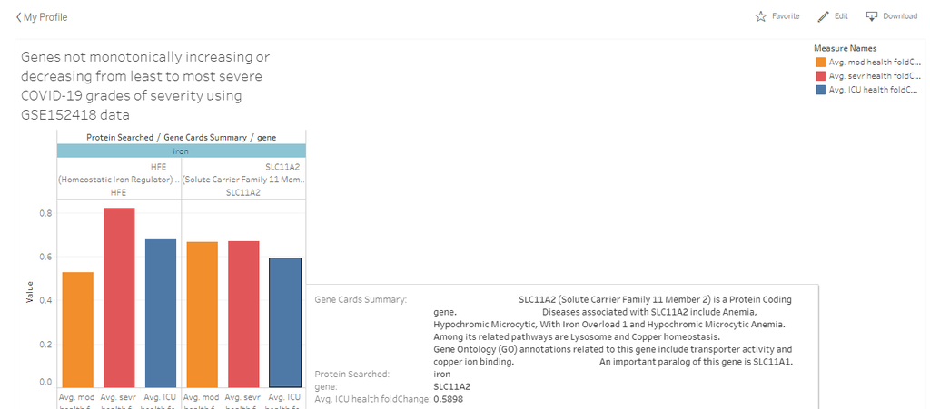

nonMonotonic Genes-Iron

This image above is of those iron genes that aren’t monotonically increasing or decreasing. There fold change values are shown for each gene and all are under expressed in the disease state compared to the healthy state. We created the rules for these fold change values so that if the disease state mean was 0 and the healthy mean was not 0, the fold change would be 1-healthy mean, and if both the disease state and the healthy state means were 0 then the fold change value would be 1, and finally if the healthy mean was 0 but the disease mean was not 0 the value would be the disease state. And if the fold change was not 0, Inf, or NaN, then the value would stay as is from the disease state/healthy state ratio of mean values. We can see from the image of the Tableau chart, that the iron gene was clicked on and selected to ‘keep only’ so that only the iron genes are displayed among those nonmonotonic. HFE and SLC11A2 are shown, and the ICU grade of COVID-19 severity is lower than the severe grade of COVID-19, but the moderate grade is lower than the ICU grade in the HFE gene and higher in the SLC11A2 gene. SLC11A2 is involved in transporter activity and copper ion binding and associated with anemia (not enough red blood cells). While HFE is associated with hemochromatosis (too many red blood cells) and signaling receptor binding as well as peptide antigen binding.

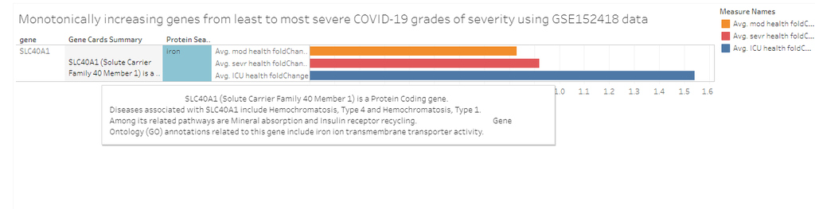

monotonic increasing fold changes-iron

The image above is of those genes monotonically increasing but with iron selected as the ‘keep only’ gene to be displayed. We can see the description of this gene that is one of the top three ranked iron genes, SLC40A1, as associated with hemochromatosis Type I and Type 4, iron ion transmembrane transporter activity, and its related pathways include mineral absorption and insulin receptor recycling.

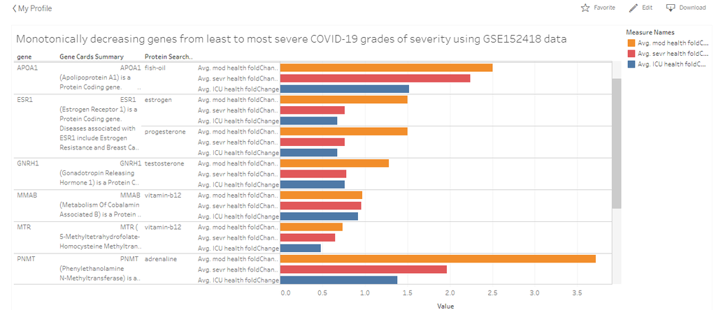